# PROJECT INTRODUCTION

This data analysis was based on the dataset of passengers on the pulley 'Titanic', which sank in 1912, further description about this dataset can be found from here: https://www.kaggle.com/c/titanic/data

# QUESTIONS OF INTEREST

#### 1. What is the correlation between survival chance and the number of family members (e.g. spouses, parents and children)?

#### 2. How does the probabily of survival differ with age.

#### 3. Do sexuality and ticket classes influence the survival chance?

# Let's start by loading the csv file into dataframe

```python
import pandas as pd
passengers_info = pd.read_csv('titanic-data.csv')
```

### Let's take a look the data

```python
passengers_info.head(10)
```

|  | PassengerId | Survived | Pclass | Name | Sex | Age | SibSp | Parch | Ticket | Fare | Cabin | Embarked |
| --- | --- | --- | --- | --- | --- | --- | --- | --- | --- | --- | --- | --- |
| 0 | 1 | 0 | 3 | Braund, Mr. Owen Harris | male | 22.0 | 1 | 0 | A/5 21171 | 7.2500 | NaN | S |
| 1 | 2 | 1 | 1 | Cumings, Mrs. John Bradley (Florence Briggs Th... | female | 38.0 | 1 | 0 | PC 17599 | 71.2833 | C85 | C |
| 2 | 3 | 1 | 3 | Heikkinen, Miss. Laina | female | 26.0 | 0 | 0 | STON/O2. 3101282 | 7.9250 | NaN | S |
| 3 | 4 | 1 | 1 | Futrelle, Mrs. Jacques Heath (Lily May Peel) | female | 35.0 | 1 | 0 | 113803 | 53.1000 | C123 | S |
| 4 | 5 | 0 | 3 | Allen, Mr. William Henry | male | 35.0 | 0 | 0 | 373450 | 8.0500 | NaN | S |
| 5 | 6 | 0 | 3 | Moran, Mr. James | male | NaN | 0 | 0 | 330877 | 8.4583 | NaN | Q |
| 6 | 7 | 0 | 1 | McCarthy, Mr. Timothy J | male | 54.0 | 0 | 0 | 17463 | 51.8625 | E46 | S |
| 7 | 8 | 0 | 3 | Palsson, Master. Gosta Leonard | male | 2.0 | 3 | 1 | 349909 | 21.0750 | NaN | S |
| 8 | 9 | 1 | 3 | Johnson, Mrs. Oscar W (Elisabeth Vilhelmina Berg) | female | 27.0 | 0 | 2 | 347742 | 11.1333 | NaN | S |
| 9 | 10 | 1 | 2 | Nasser, Mrs. Nicholas (Adele Achem) | female | 14.0 | 1 | 0 | 237736 | 30.0708 | NaN | C |

# Let's dive in questions

## QUESTION 1:

### correlation between survival chance with number of family members

In order to answer this quesition, we need to define the term "number of family menbers".

#### If we take a look at the table, there are two variables related to numbers of family members :

1. 'SibSp': the number of siblings / spouses aboard the Titanic
2. 'Parch': the number of of parents / children aboard the Titanic

In our case, we don't really care about the difference between these two variables, so we simply sum them up

### 1. 1. Create a dataframe of number of family members

```python
# add up two colums 'sibsp' and 'parch'
num_family_members = passengers_info[['SibSp','Parch']].sum(axis = 1)
new_dataframe = pd.DataFrame({'Survived':passengers_info['Survived'], 'NumF': num_family_members})
numf_and_survived = new_dataframe.groupby('NumF')
```

```python
# count the total number of people in each groups
total_num_people= numf_and_survived.count()
total_num_people
```

| NumF | Survived |
| --- | --- |
| 0 | 537 |
| 1 | 161 |
| 2 | 102 |
| 3 | 29 |
| 4 | 15 |
| 5 | 22 |
| 6 | 12 |
| 7 | 6 |
| 10 | 7 |

```python
# count the total number of survivors in each group
num_of_survived = numf_and_survived.sum()
num_of_survived
```

| NumF | Survived |
| --- | --- |
| 0 | 163 |
| 1 | 89 |
| 2 | 59 |
| 3 | 21 |
| 4 | 3 |
| 5 | 3 |
| 6 | 4 |
| 7 | 0 |
| 10 | 0 |

```python
# merge two dataframes together
merged_df = pd.DataFrame({})
merged_df['NumF'] = num_of_survived.index
merged_df['Total'] = total_num_people
merged_df['Survived'] = num_of_survived
merged_df
```

|  | NumF | Total | Survived |
| --- | --- | --- | --- |
| 0 | 0 | 537.0 | 163.0 |
| 1 | 1 | 161.0 | 89.0 |
| 2 | 2 | 102.0 | 59.0 |
| 3 | 3 | 29.0 | 21.0 |
| 4 | 4 | 15.0 | 3.0 |
| 5 | 5 | 22.0 | 3.0 |
| 6 | 6 | 12.0 | 4.0 |
| 7 | 7 | 6.0 | 0.0 |
| 8 | 10 | NaN | NaN |

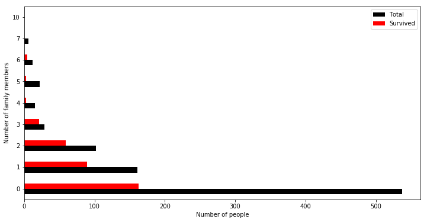

```python
import matplotlib.pyplot as plt
%pylab inline
merged_df.groupby('NumF').sum().plot(figsize=(12,6),kind = 'barh', color=['black','red'])
plt.ylabel('Number of family members')
plt.xlabel('Number of people')
```

### 1. 2. Calculate survival chances for each group

#### Here we define the survival chance by:

$$ P(A) = \frac{n(A)}{N(A)} $$
Where n (A) is the number of people who survived in group A and N is the total number of people in this group.

```python
# creating a df contaning survival chance for each group
survival_chance_df = pd.DataFrame({'NumF':merged_df['NumF']
                                   ,'Chance':numf_and_survived.mean()['Survived']})
survival_chance_df
```

|  | Chance | NumF |
| --- | --- | --- |
| 0 | 0.303538 | 0.0 |
| 1 | 0.552795 | 1.0 |
| 2 | 0.578431 | 2.0 |
| 3 | 0.724138 | 3.0 |
| 4 | 0.200000 | 4.0 |
| 5 | 0.136364 | 5.0 |
| 6 | 0.333333 | 6.0 |
| 7 | 0.000000 | 7.0 |
| 8 | NaN | 10.0 |
| 10 | 0.000000 | NaN |

### 1.3 Data visualization

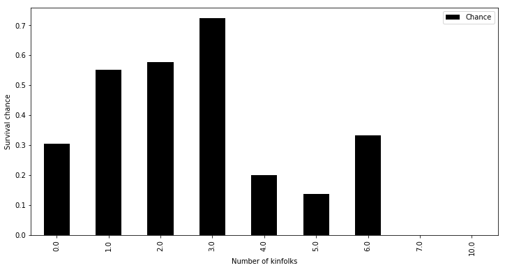

```python
import matplotlib.pyplot as plt
%pylab inline


survival_chance_df.groupby('NumF').sum().plot(kind = 'bar', figsize = (12,6), color = 'black')
plt.xlabel('Number of kinfolks')
plt.ylabel('Survival chance')
```

## Question 2: Correlation with age and survival chance

```python
passengers_info['Age'].head(10)
```

```
0    22.0
1    38.0
2    26.0
3    35.0
4    35.0
5     NaN
6    54.0
7     2.0
8    27.0
9    14.0
Name: Age, dtype: float64
```

### 2.1. Data cleaning

It seems some age information are missing, and we need to take care of it.

```python
# simply get rid of missing data points
age_and_survival_df = passengers_info[['Age', 'Survived']].dropna()
age_and_survival_df.head(10)
```

|  | Age | Survived |
| --- | --- | --- |
| 0 | 22.0 | 0 |
| 1 | 38.0 | 1 |
| 2 | 26.0 | 1 |
| 3 | 35.0 | 1 |
| 4 | 35.0 | 0 |
| 6 | 54.0 | 0 |
| 7 | 2.0 | 0 |
| 8 | 27.0 | 1 |
| 9 | 14.0 | 1 |
| 10 | 4.0 | 1 |

```python
# here we assign age into different groups, with binsize at 10
bins = np.arange(0,90,10)
age_and_survival_df['Age_group'] = pd.cut(age_and_survival_df['Age'],bins)
age_and_survival_df.groupby(["Age_group"])['Survived'].sum()
```

```
Age_group
(0, 10]     38
(10, 20]    44
(20, 30]    84
(30, 40]    69
(40, 50]    33
(50, 60]    17
(60, 70]     4
(70, 80]     1
Name: Survived, dtype: int64
```

```python
# Create a new df containning the number of survivors and total number of people in each group
new_age_group = pd.DataFrame({})
new_age_group['Survived']  = age_and_survival_df.groupby(["Age_group"])['Survived'].sum()
new_age_group['Total'] = age_and_survival_df.groupby(["Age_group"])['Survived'].count()
new_age_group
```

| Age_group | Survived | Total |
| --- | --- | --- |
| (0, 10] | 38 | 64 |
| (10, 20] | 44 | 115 |
| (20, 30] | 84 | 230 |
| (30, 40] | 69 | 155 |
| (40, 50] | 33 | 86 |
| (50, 60] | 17 | 42 |
| (60, 70] | 4 | 17 |
| (70, 80] | 1 | 5 |

### 2.2. Calculate survival chance for age

#### Here we define the survival chance by:

$$ P(A) = \frac{n(A)}{N(A)} $$
Where n (A) is the number of people who survived at age A and N is the total number of people at age A.

```python
survival_chance_in_age_groups = new_age_group['Survived']/new_age_group['Total']
survival_chance_in_age_groups
```

```
Age_group
(0, 10]     0.593750
(10, 20]    0.382609
(20, 30]    0.365217
(30, 40]    0.445161
(40, 50]    0.383721
(50, 60]    0.404762
(60, 70]    0.235294
(70, 80]    0.200000
dtype: float64
```

### 2.3. Investigate correlation between age and survive

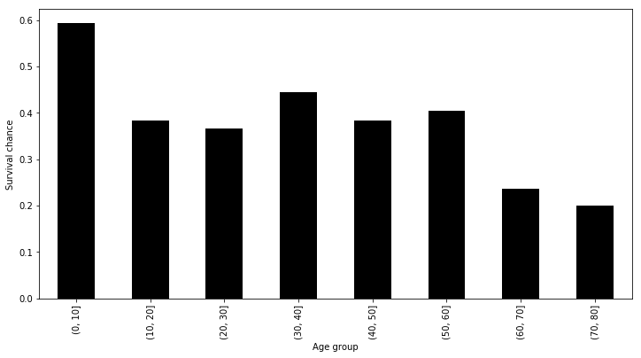

```python
import matplotlib.pyplot as plt
%pylab inline

survival_chance_in_age_groups.plot(kind = 'bar', color = 'black', figsize = (12,6))
plt.xlabel('Age group')
plt.ylabel('Survival chance')
```

```python
survival_chance_in_age_groups.describe()
```

```
count    8.000000
mean     0.376314
std      0.121901
min      0.200000
25%      0.332737
50%      0.383165
75%      0.414862
max      0.593750
dtype: float64
```

### 2.4. Conclusion

- The distribution pattern of survival chance wrt. age groups is not clear
- The average survival chance in all age groups is 37.6% ± 12.1%
- Children and infants (0 - 10 years old) had highest survival chance at 59.4%, whereas the elders (70 - 80) had lowest one.
- Given some missing data points were deleted at the stage of data cleaning, the result might not be representitive.

## QUESTION 3: Survival chance wrt. ticket classes & sexuality

### 3.1. Correlation between classes and survival chance

```python
# create a dataframe containing ticket classes, number of survivors, total number of people
ticket_classes_df = pd.DataFrame({})
ticket_classes_df['Survived'] = passengers_info.groupby('Pclass').sum()['Survived']
ticket_classes_df['Total'] = passengers_info.groupby('Pclass').count()['Survived']
ticket_classes_df
```

| Pclass | Survived | Total |
| --- | --- | --- |
| 1 | 136 | 216 |
| 2 | 87 | 184 |
| 3 | 119 | 491 |

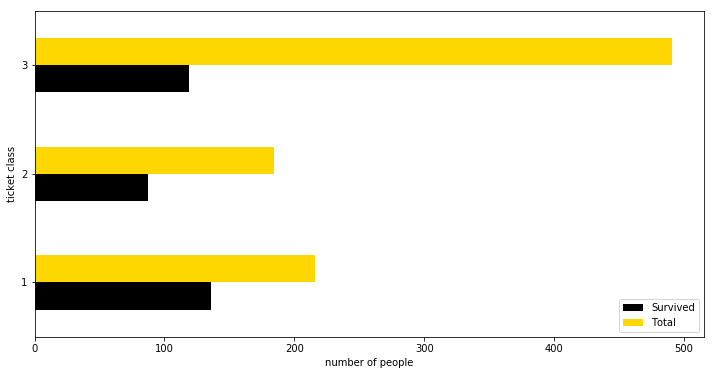

```python
import matplotlib.pyplot as plt
%pylab inline

ticket_classes_df.plot(kind = 'barh',figsize = (12,6), color = ('black','gold'))
plt.ylabel('ticket class')
plt.xlabel('number of people')
```

```python
# calculate survival chance for passengers with different tickets
ticket_classes_chance_df = ticket_classes_df['Survived'] / ticket_classes_df['Total']
ticket_classes_chance_df
```

```
Pclass
1    0.629630
2    0.472826
3    0.242363
dtype: float64
```

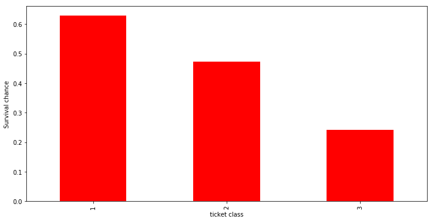

```python
%pylab inline
import matplotlib.pyplot as plt

ticket_classes_chance_df.plot(kind = 'bar',figsize = (12,6), color = ('red'))
plt.ylabel('Survival chance')
plt.xlabel('ticket class')
```

### 3.2. Correlation between sexuality and survival chance

```python
# creat a dataframe containing info about 1. # male and female survivors 2. total # of female and males
sex_df = pd.DataFrame({})
sex_df['Survived'] = passengers_info.groupby('Sex').sum()['Survived']
sex_df['Total'] = passengers_info.groupby('Sex').count()['Survived']
sex_df
```

| Sex | Survived | Total |
| --- | --- | --- |
| female | 233 | 314 |
| male | 109 | 577 |

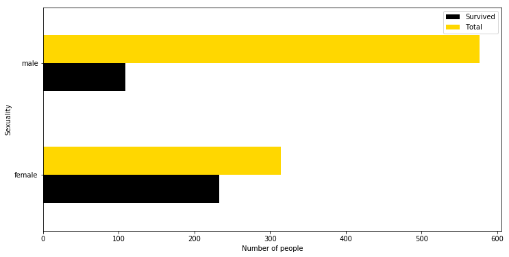

```python
%pylab inline
import matplotlib.pyplot as plt

sex_df.plot(kind = 'barh',figsize = (12,6), color = ('black','gold'))
plt.ylabel('Sexuality')
plt.xlabel('Number of people')
```

```python
# calculate the survival chance for females and males
sex_chance_df = sex_df['Survived'] / sex_df['Total']
sex_chance_df
```

```
Sex
female    0.742038
male      0.188908
dtype: float64
```

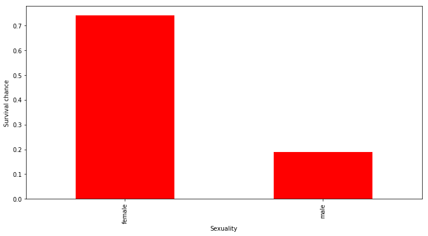

```python
%pylab inline
import matplotlib.pyplot as plt

sex_chance_df.plot(kind = 'bar',figsize = (12,6), color = ('red'))
plt.ylabel('Survival chance')
plt.xlabel('Sexuality')
```

### 3.3. Combination of two variables

#### 3.3.1. number of survivors and total number of passengers in each group

```python
sex_and_class_df = pd.DataFrame({})
sex_and_class_df['Survived'] = passengers_info.groupby(['Sex', 'Pclass']).sum()['Survived']
sex_and_class_df['Total'] = passengers_info.groupby(['Sex', 'Pclass']).count()['Survived']
sex_and_class_df
```

| Sex | Pclass | Survived | Total |
| --- | --- | --- | --- |
| female | 1 | 91 | 94 |
|  | 2 | 70 | 76 |
|  | 3 | 72 | 144 |
| male | 1 | 45 | 122 |
|  | 2 | 17 | 108 |
|  | 3 | 47 | 347 |

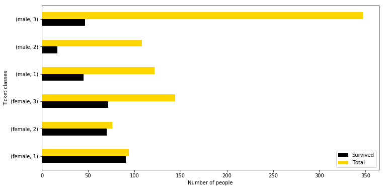

```python
%pylab inline
import matplotlib.pyplot as plt


sex_and_class_df.plot(kind = 'barh',figsize = (12,6), color = ('black','gold'))
plt.ylabel('Ticket classes')
plt.xlabel('Number of people')
```

#### 3.3.2. Calculate survival chance in each group

```python
survival_chance_sex_and_class = sex_and_class_df['Survived'] / sex_and_class_df['Total']
survival_chance_in_age_groups
```

```
Age_group
(0, 10]     0.593750
(10, 20]    0.382609
(20, 30]    0.365217
(30, 40]    0.445161
(40, 50]    0.383721
(50, 60]    0.404762
(60, 70]    0.235294
(70, 80]    0.200000
dtype: float64
```

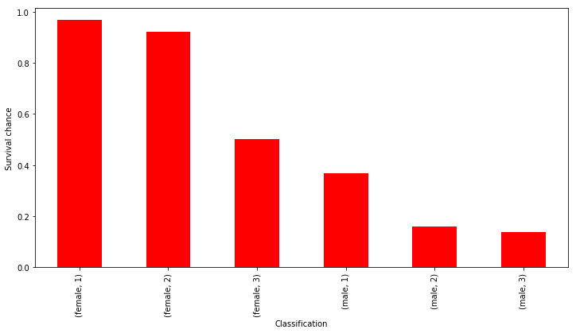

```python
%pylab inline
import matplotlib.pyplot as plt

survival_chance_sex_and_class.plot(kind = 'bar',figsize = (12,6), color = ('red'))
plt.ylabel('Survival chance')
plt.xlabel('Classification')
```

```python
survival_chance_sex_and_class.describe()
```

```
count    6.000000
mean     0.508474
std      0.364260
min      0.135447
25%      0.210269
50%      0.434426
75%      0.815789
max      0.968085
dtype: float64
```

### 3.4. Conclusion

- The trend in terms of sexuality is quite obivious: females passengers had significantly higher survival chance than males.
- The survival chance decreases as the ticket class gets lower (i.e. passengers with 1st class ticket have highest probability of survival, followed by 2nd class).
- Almost every women in with 1st and 2nd class tickets survived (survival chance: aprox. 96%), whereas only 13.5% males with 3rd class ticked survived